# Team-1-Lab4

Hidden Markov Models

Tina Tao

2025-05-16

# Load Packages

```r
library(dplyr)
#install.packages("rsoi")
#install.packages("depmixS4")
library(rsoi)
library(depmixS4)
```

```r
library(ggplot2)
```

As part of the California Current Integrated Ecosystem Report, NOAA scientists do annual updates of [stoplight charts for ecosystem indicators](https://www.fisheries.noaa.gov/west-coast/science-data/ocean-conditions-indicators-trends).

Describe what plankton groups and covariates you used and indicate any temporal subsetting you chose. Also describe any standardization, centering or scaling that was used.

# Load Data

One of the columns divides indicators into groups (e.g. Local Physical, Local Biological, etc).

```r
pdo <- rsoi::download_pdo()
stoplight <- read.csv("stoplight.csv")
```

# Data Processing

```r
# Look at the winter PDO only, need to shift the year for Oct-Dec by 1 since Oct-Feb spans 2 calendar years
pdo$Year[which(pdo$Month%in%c("Oct","Nov","Dec"))] <- pdo$Year[which(pdo$Month%in%c("Oct","Nov","Dec"))] + 1
pdo <- dplyr::group_by(pdo, Year) %>%
  dplyr::summarize(winter_pdo = mean(PDO[which(Month %in% c("Oct","Nov","Dec","Jan","Feb"))])) %>%
  dplyr::select(winter_pdo, Year)

# The first year will be missing Oct-Dec
pdo <- pdo[-1,]
```

# Data Visualization

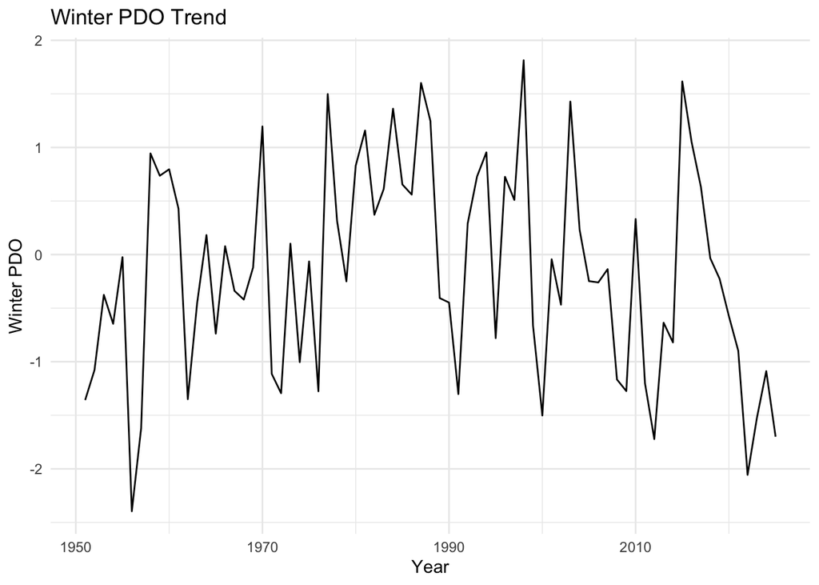

```r
pdo_plot <- ggplot(pdo, aes(x = Year, y = winter_pdo)) +
  geom_line() +
  labs(title = "Winter PDO Trend", x = "Year", y = "Winter PDO") +
  theme_minimal()

pdo_plot
```

## Question 1.

Fit a 2-state HMM to the annual indices of winter PDO. Assume Gaussian errors (default).

```r
# Prepare data for depmixS4
winter_pdo <- data.frame(winter_pdo = pdo$winter_pdo)

# Define HMM with 2 hidden states and Gaussian distribution
pdo_hmm_model <- depmix(response = winter_pdo ~ 1,
                    data = winter_pdo,
                    nstates = 2,
                    family = gaussian())

# Fit the model
pdo_hmm_fit <- fit(pdo_hmm_model, verbose = TRUE)
```

```
## iteration 0 logLik: -104.7527
## iteration 5 logLik: -104.7353
## iteration 10 logLik: -104.6903
## iteration 15 logLik: -104.5765
## iteration 20 logLik: -104.2382
## iteration 25 logLik: -101.484
## iteration 30 logLik: -97.20829
## iteration 35 logLik: -96.44929
## iteration 40 logLik: -96.20731
## iteration 45 logLik: -96.1683
## iteration 50 logLik: -96.16462
## iteration 55 logLik: -96.16434
## iteration 60 logLik: -96.16432
## converged at iteration 61 with logLik: -96.16431
```

```r
# Summary of the fitted HMM
summary(pdo_hmm_fit)
```

```
## Initial state probabilities model
## pr1 pr2
##   0   1
##
## Transition matrix
##         toS1  toS2
## fromS1 0.707 0.293
## fromS2 0.168 0.832
##
## Response parameters
## Resp 1 : gaussian
##     Re1.(Intercept) Re1.sd
## St1           0.853  0.502
## St2          -0.733  0.669
```

## Question 2.

Try fitting the model 10-20 times. Does the likelihood seem reasonably stable?

```r
# Yes, the likelihood is stable. The values of the log-likelihood are similar across multiple fits.
```

[output not shown]

[output not shown]

## Question 3.

What is the transition matrix for the best model? What are the persistence probabilities (e.g. probabilities of staying in the same state from step 𝑡 to 𝑡+1)?

```r
# Find best model (try 1-2 states)
model_list <- list()
fit_list <- list()
aic_values <- numeric(2)

for (k in 1:2) {
  set.seed(550)
  model <- depmix(response = winter_pdo ~ 1,
                  data = winter_pdo,
                  nstates = k,
                  family = gaussian())
  fit_model <- fit(model, verbose = FALSE)
  model_list[[k]] <- model
  fit_list[[k]] <- fit_model
  aic_values[k] <- AIC(fit_model)
}
```

```
## converged at iteration 1 with logLik: -104.7535
## converged at iteration 48 with logLik: -96.16431
```

```r
aic_table <- data.frame(States = 1:2, AIC = aic_values)
print(aic_table)
```

```
##   States      AIC
## 1      1 213.5070
## 2      2 206.3286
```

```r
best_k <- which.min(aic_values)
pdo_hmm_best_fit <- fit_list[[best_k]]

# Extract transition matrix from best model (if k > 1)
if (best_k > 1) {
  best_fit <- fit_list[[best_k]]
  trans_mat <- matrix(NA, best_k, best_k)

  for (i in 1:best_k) {
    coefs <- best_fit@transition[[i]]@parameters$coefficients
    exp_coefs <- exp(coefs)
    trans_mat[i, ] <- exp_coefs / sum(exp_coefs)
  }

  rownames(trans_mat) <- paste0("fromState", 1:best_k)
  colnames(trans_mat) <- paste0("toState", 1:best_k)

  cat("\nTransition Matrix:\n")
  print(trans_mat)

  # Persistence probabilities (diagonal)
  persistence <- diag(trans_mat)
  cat("\nPersistence Probabilities:\n")
  print(persistence)
} else {
  cat("No transition matrix for 1-state model (no state switching).\n")
}
```

```
##
## Transition Matrix:
##             toState1  toState2
## fromState1 0.6021715 0.3978285
## fromState2 0.3399939 0.6600061
##
## Persistence Probabilities:
## [1] 0.6021715 0.6600061
```

## Question 4.

Plot the predicted values versus year.

```r
predicted_states <- posterior(pdo_hmm_best_fit)
```

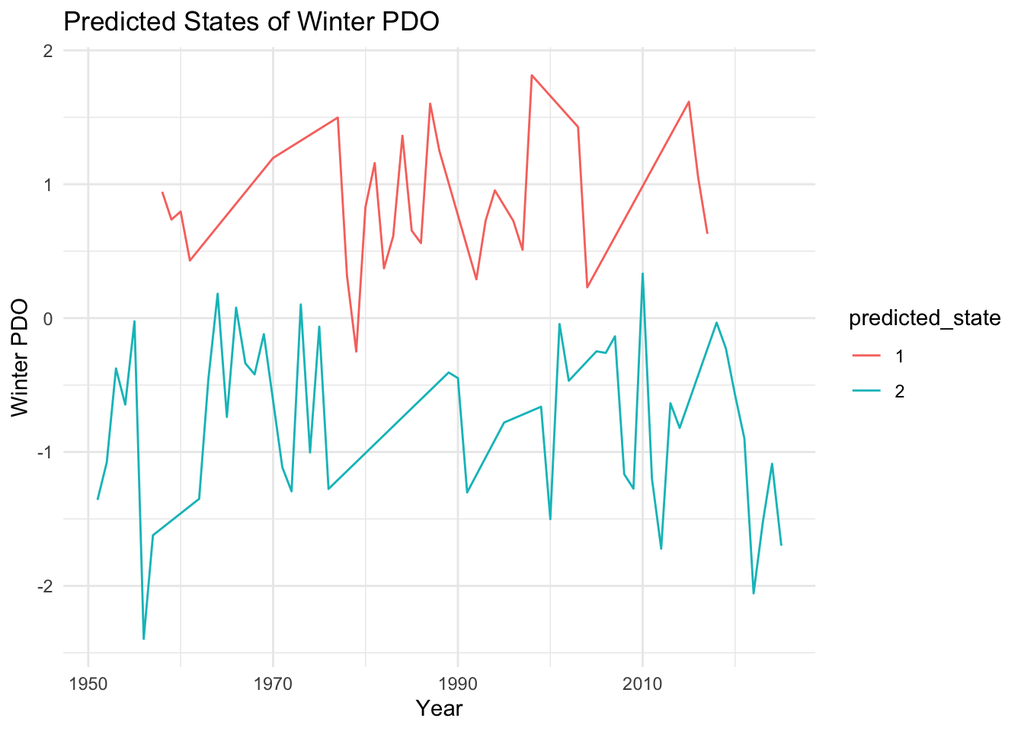

```r
winter_pdo$predicted_state <- predicted_states$state
winter_pdo$Year <- pdo$Year
winter_pdo$Year <- as.numeric(winter_pdo$Year)
winter_pdo$predicted_state <- as.factor(winter_pdo$predicted_state)
winter_pdo_plot <- ggplot(winter_pdo, aes(x = Year, y = winter_pdo, color = predicted_state)) +
  geom_line() +
  labs(title = "Predicted States of Winter PDO", x = "Year", y = "Winter PDO") +
  theme_minimal()
winter_pdo_plot
```

## Question 5.

Plot the posterior probability of being in the various states from your best model (e.g. probability of being in state 1 over time)

```r
posterior_probs <- posterior(pdo_hmm_best_fit)
```

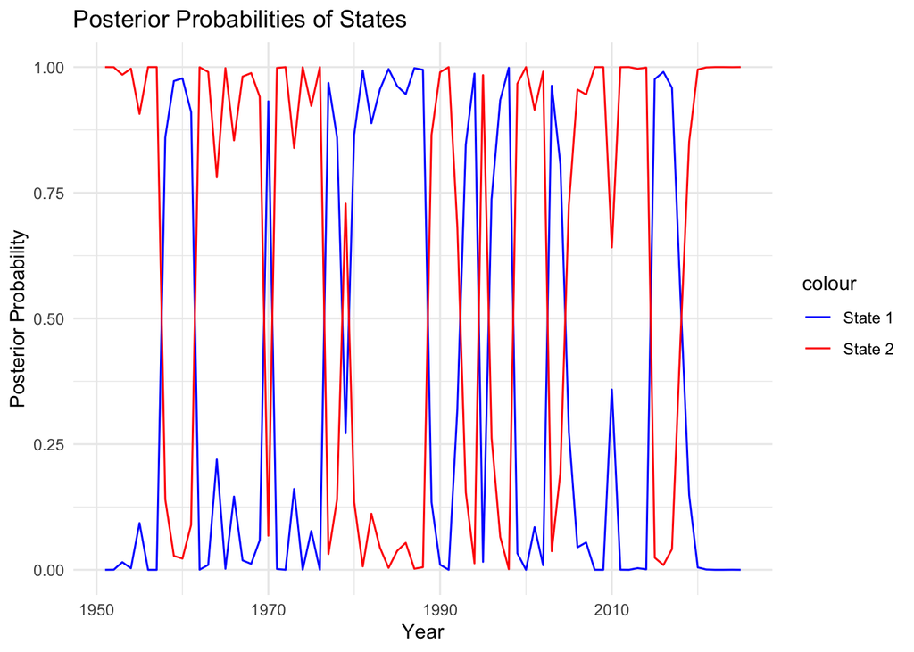

```r
winter_pdo$posterior_prob_state1 <- posterior_probs$S1
winter_pdo$posterior_prob_state2 <- posterior_probs$S2
winter_pdo_plot_posterior <- ggplot(winter_pdo, aes(x = Year)) +
  geom_line(aes(y = posterior_prob_state1, color = "State 1")) +
  geom_line(aes(y = posterior_prob_state2, color = "State 2")) +
  labs(title = "Posterior Probabilities of States", x = "Year", y = "Posterior Probability") +
  scale_color_manual(values = c("State 1" = "blue", "State 2" = "red")) +
  theme_minimal()
winter_pdo_plot_posterior
```